# 例二： 植物生理参数对模型的的影响

主讲人： 杨金炎  
2022-06-29

## 增加新物种

增加物种需要修改的输入有species、thinning、parameters以及size_dist。其中，尤其以parameters最为重要。下面我们依次介绍需要进行的修改。

### 1 查看现有物种信息

首先，可以查看现有的文献当中，覆盖哪些地区和物种。

```r
list.spc <- get_parameters(mode = "overview", sp_names = NULL)

head(list.spc)
```

```
  parset_id             species  age type year
1         1   Tamaulipan shrubs even mono 2016
2         2 Eucalyptus globulus even mono 2016
3         3  Eucalyptus grandis even mono 2016
4         4  Eucalyptus grandis even mono 2004
5         5  Eucalyptus grandis even mono 2004
6         6  Eucalyptus grandis even mono 2004
                            region           country
1 Lower Rio Grande Valley, TX, USA               USA
2             Australia and Brazil Australia, Brazil
3             Australia and Brazil Australia, Brazil
4                             <NA>            Brazil
5                             <NA>            Brazil
6                             <NA>            Brazil
                   source
1 Adhikari and White 2016
2  Almeida and Sands 2016
3  Almeida and Sands 2016
4     Almeida et al. 2004
5     Almeida et al. 2004
6     Almeida et al. 2004
```

如果我们感兴趣的物种在以往的文献中出现，那么我们就可以直接用文献中的数据。在此，我们以Larix olgensis为例。

```r
lo.df <- get_parameters(mode = "full", sp_names = 'Larix olgensis')

print(lo.df)
```

```
    parset_id        species  age type year             region
107       107 Larix olgensis even mono 2017 northeastern China
108       108 Larix olgensis even mono 2020 northeastern China
109       109 Larix olgensis even mono 2020 northeastern China
    country
107   China
108   China
109   China
                                                                                                                                                                                                                                                                                                            …
107 Please note that this parameter set requires an assumption that the leaves remain on this deciduous species during winter. They also continue to function during winter (unless the Tmin parameter prevents it) and no new leaves need to be produced in spring (they just start functioning again). The…
108                                                                                                                                                                                                                                                                                                         …
109                                                                                                                                                                                                                                                                                                         …
             source source_comments
107 Xie et al. 2017            <NA>
108 Xie et al. 2020            <NA>
```

[output cut: 61 more lines]

### 2 现有物种参数处理

```r
# 此处我们去掉关于数据来源的前几列
lo.sub <- subset(lo.df[2,],select = -c(source_full,species,
                                       link,notes,parset_id,
                                       source,source_comments,
                                       country,age,type,year,region))
# 修改数据结构
lo.sub.long <- as.data.frame(t(lo.sub))
names(lo.sub.long) <- 'Larix olgensis'
lo.sub.long$parameter <- row.names(lo.sub.long)
print(lo.sub.long)
```

```
              Larix olgensis     parameter
pFS2                   0.900          pFS2
pFS20                  0.500         pFS20
aWS                    0.016           aWS
nWS                    2.796           nWS
pRx                    0.800           pRx
pRn                    0.300           pRn
gammaF1                0.057       gammaF1
gammaF0                0.001       gammaF0
tgammaF                   NA       tgammaF
gammaR                    NA        gammaR
leafgrow               5.000      leafgrow
leaffall              10.000      leaffall
Tmin                  -5.000          Tmin
Topt                  16.000          Topt
Tmax                  38.000          Tmax
kF                     1.000            kF
SWconst                   NA       SWconst
SWpower                   NA       SWpower
fCalpha700                NA    fCalpha700
fCg700                    NA        fCg700
m0                        NA            m0
fN0                       NA           fN0
fNn                       NA           fNn
MaxAge               160.000        MaxAge
nAge                   4.000          nAge
rAge                   0.800          rAge
gammaN1                3.000       gammaN1
gammaN0                0.000       gammaN0
tgammaN                   NA       tgammaN
ngammaN                1.000       ngammaN
wSx1000               70.571       wSx1000
thinPower              1.500     thinPower
mF                     0.000            mF
mR                     0.200            mR
mS                     0.200            mS
SLA0                      NA          SLA0
SLA1                   8.026          SLA1
tSLA                      NA          tSLA
k                         NA             k
```

[output cut: 58 more lines]

```
wsscaleC                  NA      wsscaleC
wsshape0                  NA      wsshape0
wsshapeB                  NA      wsshapeB
wsshaperh                 NA     wsshaperh
wsshapet                  NA      wsshapet
wsshapeC                  NA      wsshapeC
wslocation0               NA   wslocation0
wslocationB               NA   wslocationB
wslocationrh              NA  wslocationrh
wslocationt               NA   wslocationt
wslocationC               NA   wslocationC
Qa                   -90.000            Qa
Qb                     0.800            Qb
gDM_mol                   NA       gDM_mol
molPAR_MJ              2.300     molPAR_MJ
```

现在我们可以把新物种加入到参数列表中。需要注意的是有很多参数该文献没有提供。处理这些缺失参数应当考虑缺失参数的重要性和是否有其他类似物种可以提供替代。在此例子中，我们简单选用Fagus sylvatica的参数替代缺失参数。

```r
par.new <- merge(d_parameters,lo.sub.long)

na.index <- which(is.na(par.new$`Larix olgensis`))

par.new[na.index,4] <- par.new[na.index,2]

print(par.new)
```

```
       parameter Fagus sylvatica Pinus sylvestris Larix olgensis
1     aFracDiffu      4.40000000       4.40000000      4.4000000
2             aH      1.00792694       4.58868532      3.6630000
3            aHL      6.26900373       2.18857916      6.2690037
4             aK      0.93895242       1.37649061      0.9389524
5        alphaCx      0.04981007       0.04856557      0.0380000
6             aV      0.00000000       0.00000000      0.0000000
7            aWS      0.18338848       0.12591686      0.0160000
8      bFracRubi     27.00000000      27.00000000     27.0000000
9         BLcond      0.20000000       0.20000000      0.2000000
10     CoeffCond      0.05700000       0.05000000      0.0500000
11    crownshape      3.00000000       3.00000000      3.0000000
12          cVPD      5.00000000       5.00000000      5.0000000
13 D13CTissueDif      2.00000000       2.00000000      2.0000000
14    fCalpha700      1.00000000       1.00000000      1.0000000
```

[output cut: 68 more lines]

### 3 修改相应其他输入数据

```r
spc.new <- d_species

spc.new[3,] <- list('Larix olgensis','1958-01',0.25,800,90,15.2,3)

spc.new$fertility <- c(0.3,0.3,0.3)
spc.new$stems_n <-  500
spc.new$biom_stem <-  60
spc.new$biom_root <-  8
spc.new$biom_foliage <-  1.5
print(spc.new)
```

```
           species planted fertility stems_n biom_stem biom_root
1  Fagus sylvatica 1958-01       0.3     500        60         8
2 Pinus sylvestris 1958-01       0.3     500        60         8
3   Larix olgensis 1958-01       0.3     500        60         8
  biom_foliage
1          1.5
2          1.5
3          1.5
```

最后，需要修改thinning数据。此处我们使用Fagus sylvatica的数据。

```r
thin.new <- d_thinning

thin.new[3,] <- d_thinning[1,]

thin.new$species[3] <- 'Larix olgensis'

thin.new$age <- 200

print(thin.new)
```

```
           species age stems_n stem root foliage
1  Fagus sylvatica 200     500    1    1       1
2 Pinus sylvestris 200     600    1    1       1
3   Larix olgensis 200     500    1    1       1
```

此处我们不需要修改sizeDist参数。具体原因如前所述-此处不需要修正异速生长关系。以下代码可以作为参考。

```r
size.new <- d_sizeDist

size.new[,4] <- d_sizeDist[,2]

names(size.new)[4] <- 'Larix olgensis'

print(size.new)
```

```
      parameter Fagus sylvatica Pinus sylvestris Larix olgensis
1       Dscale0       0.1943880       0.27800157      0.1943880
2       DscaleB       1.2246192       1.15180270      1.2246192
3      Dscalerh       0.0000000       0.00000000      0.0000000
4       Dscalet       0.1277694       0.00000000      0.1277694
5       DscaleC       0.0000000       0.05427770      0.0000000
6       Dshape0       0.7881010       1.22831560      0.7881010
7       DshapeB       0.3161924       0.00000000      0.3161924
8      Dshaperh       1.6142477       1.18896340      1.6142477
9       Dshapet       0.0000000       0.00000000      0.0000000
10      DshapeC      -0.1170241       0.21436780     -0.1170241
11   Dlocation0       1.6360919       0.98723714      1.6360919
12   DlocationB       0.5046618       0.87204890      0.5046618
13  Dlocationrh      -0.6263416       0.02258520     -0.6263416
14   Dlocationt       0.0000000       0.00000000      0.0000000
```

[output cut: 16 more lines]

### 4 运行新的模型

修改全部输入数据后，就可以再次运行模型。

```r
out.1 <- run_3PG(site = d_site,#站点相关信息，初始土壤水
                  species = spc.new,#树种相关信息，初始生物量
                  climate = d_climate,#气象因子
                  thinning = thin.new,#间苗
                  parameters = par.new,#按树种的生理参数
                  size_dist = size.new,#修正大小分布
                  settings = list(light_model = 2,
                                  transp_model = 2, phys_model = 2,
                                  correct_bias = 0, calculate_d13c = 0),
                  check_input = TRUE,
                  df_out = TRUE)
```

我们可以观察生产力的变化。

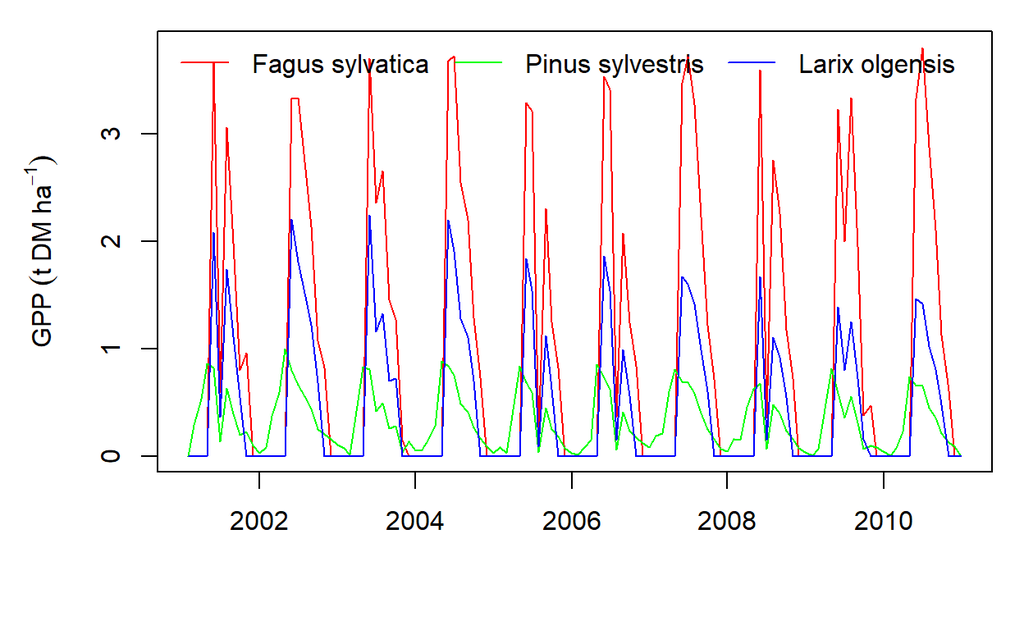

```r
par(mar=c(5,5,1,1))
palette(c(rainbow(3)))
plot(value~date,data = out.1[out.1$species == 'Fagus sylvatica' &
                                 out.1$variable == 'gpp',],
       type='l',xlab='',ylab=expression('GPP'~(t~DM~ha^-1)),col=1)

  points(value~date,data = out.1[out.1$species == 'Pinus sylvestris' &
                                   out.1$variable == 'gpp',],
         type='l',xlab='',col=2)

  points(value~date,data = out.1[out.1$species == 'Larix olgensis' &
                                   out.1$variable == 'gpp',],
         type='l',xlab='',col=3)

  legend('topleft',legend = unique(out.1$species),
         lty='solid',col=palette(),bty='n',horiz = T)
```

也可以研究不同种的组成。此处我们以总干面积为例。

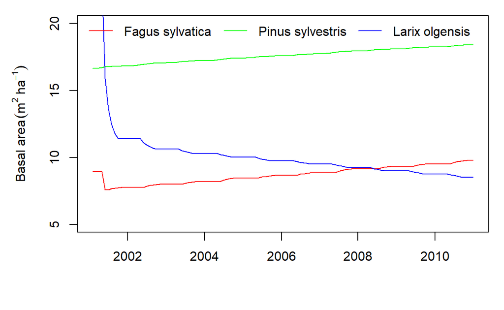

```r
par(mar=c(5,5,1,1))
palette(c(rainbow(3)))
plot(value~date,data = out.1[out.1$species == 'Fagus sylvatica' &
                                 out.1$variable == 'basal_area',],
       type='l',xlab='',
     ylab=expression('Basal area'~(m^2~ha^-1)),
     col=1,ylim=c(5,20))

  points(value~date,data = out.1[out.1$species == 'Pinus sylvestris' &
                                   out.1$variable == 'basal_area',],
         type='l',xlab='',col=2)

  points(value~date,data = out.1[out.1$species == 'Larix olgensis' &
                                   out.1$variable == 'basal_area',],
         type='l',xlab='',col=3)

  legend('topleft',legend = unique(out.1$species),
         lty='solid',col=palette(),bty='n',horiz = T)
```

### 5 具体参数的影响

我们此处以比叶面积为例。这里假设比叶面积翻倍，即单位生物量可以产出两倍的叶面积。

```r
par.new.sla <- par.new
par.new.sla$`Larix olgensis`[par.new.sla$parameter == 'SLA0'] <- 50
par.new.sla$`Larix olgensis`[par.new.sla$parameter == 'SLA1'] <- 16
```

```r
out.sla <- run_3PG(site = d_site,#站点相关信息，初始土壤水
                  species = spc.new,#树种相关信息，初始生物量
                  climate = d_climate,#气象因子
                  thinning = thin.new,#间苗
                  parameters = par.new.sla,#按树种的生理参数
                  size_dist = size.new,#修正大小分布
                  settings = list(light_model = 2,
                                  transp_model = 2, phys_model = 2,
                                  correct_bias = 0, calculate_d13c = 0),
                  check_input = TRUE,
                  df_out = TRUE)
```

我们首先可以查看叶面积的变化。

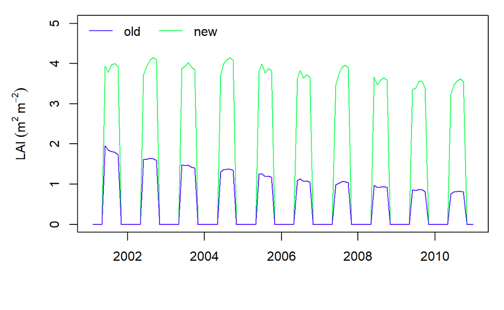

```r
par(mar=c(5,5,1,1))
palette(c(topo.colors(3)))
plot(value~date,data = out.sla[out.sla$species == 'Larix olgensis' &
                                 out.sla$variable == 'lai',],
       type='l',xlab='',ylab=expression('LAI'~(m^2~m^-2)),col=2,ylim=c(0,5))

  points(value~date,data = out.1[out.sla$species == 'Larix olgensis' &
                                   out.sla$variable == 'lai',],
         type='l',xlab='',col=1)

  legend('topleft',legend = c('old','new'),
         lty='solid',col=palette(),bty='n',horiz = T)
```

叶面积的变化对于生产力有直接影响。

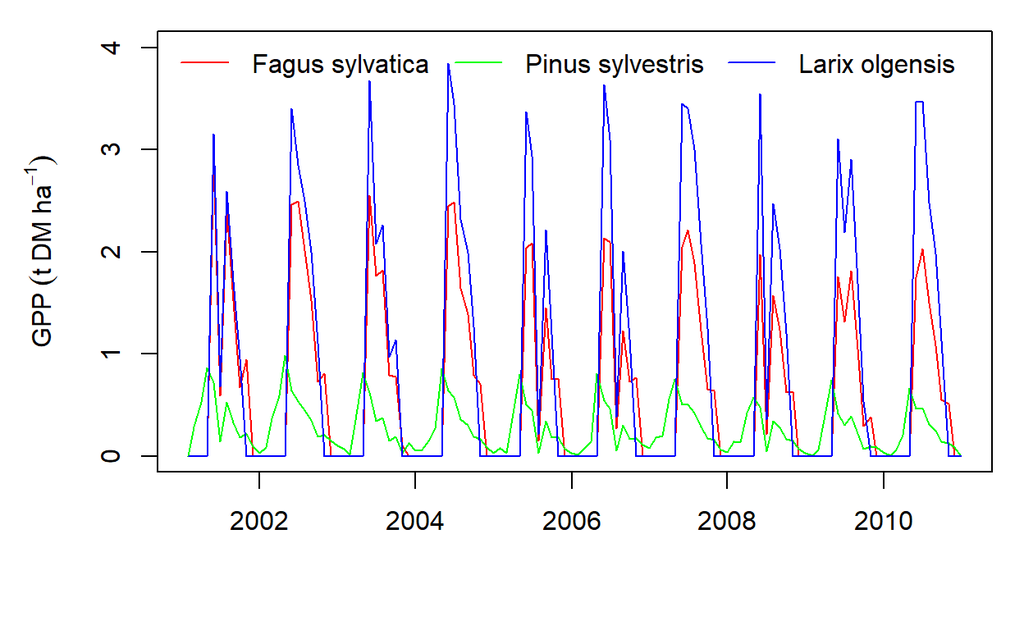

```r
par(mar=c(5,5,1,1))
palette(c(rainbow(3)))
plot(value~date,data = out.sla[out.sla$species == 'Fagus sylvatica' &
                                 out.sla$variable == 'gpp',],
       type='l',xlab='',ylab=expression('GPP'~(t~DM~ha^-1)),col=1,ylim=c(0,4))

  points(value~date,data = out.sla[out.sla$species == 'Pinus sylvestris' &
                                   out.sla$variable == 'gpp',],
         type='l',xlab='',col=2)

  points(value~date,data = out.sla[out.sla$species == 'Larix olgensis' &
                                   out.sla$variable == 'gpp',],
         type='l',xlab='',col=3)

  legend('topleft',legend = unique(out.sla$species),
         lty='solid',col=palette(),bty='n',horiz = T)
```